# Text Mining

Rachel Chang

2019/7/18

#### 動機 : 比較ptt-Finance版文章中前五個關鍵詞和文章間關聯性最高的詞差異。

reference1 : https://ntu-csx-datascience.github.io/106-2RSampleCode/week_6/course_6/PTTBoyGirl.html

reference2 : https://ntu-csx-datascience.github.io/1072-CSX4001-DataScience/CooccurrenceTextMining/TextMining.html?fbclid=IwAR3GLHyHmKw6xXwSH8g8S3-9xoRrZN2us79v7xHuy33z_7ZFwD1mqp-SU6E

### 一、挑選近一個月的文章(220篇)，找出關鍵詞

#### 安裝套件

```r
library(bitops)
library(httr)
library(RCurl)
library(XML)
library(tm)
library(NLP)
library(tmcn)
library(jiebaRD)
library(jiebaR)
library(rvest)
library(stringr)
```

#### PTT 網路爬蟲抓出所有文章內文所對應的網址

```r
from <- 1141 # 2018-06-01
to   <- 1151 # 2018-07-10
prefix = "https://www.ptt.cc/bbs/Finance/index"

data <- list()
for( id in c(from:to) )
{
  url  <- paste0( prefix, as.character(id), ".html" )
  html <- htmlParse( GET(url) )
  url.list <- xpathSApply( html, "//div[@class='title']/a[@href]", xmlAttrs )
  data <- rbind( data, as.matrix(paste('https://www.ptt.cc', url.list, sep='')) )
}
data <- unlist(data)

head(data)
```

```
## [1] "https://www.ptt.cc/bbs/Finance/M.1559354102.A.819.html"
## [2] "https://www.ptt.cc/bbs/Finance/M.1559367740.A.A0E.html"
## [3] "https://www.ptt.cc/bbs/Finance/M.1559384353.A.B64.html"
## [4] "https://www.ptt.cc/bbs/Finance/M.1559397563.A.896.html"
## [5] "https://www.ptt.cc/bbs/Finance/M.1559409207.A.B01.html"
## [6] "https://www.ptt.cc/bbs/Finance/M.1559445699.A.6FD.html"
```

#### 利用所有文章的網址去抓所有文章內文

```r
library(dplyr)
library(RCurl)
getdoc <- function(url)
{
  html <- htmlParse(getURL(url))
  doc  <- xpathSApply( html, "//div[@id='main-content']", xmlValue )
  id <- substr(url,32,49)
  name <- paste0('./DATA/', id, ".txt")
  write(doc,name, append = TRUE)}

sapply(head(data), getdoc)
```

```
## $`https://www.ptt.cc/bbs/Finance/M.1559354102.A.819.html`
## NULL
##
## $`https://www.ptt.cc/bbs/Finance/M.1559367740.A.A0E.html`
## NULL
##
## $`https://www.ptt.cc/bbs/Finance/M.1559384353.A.B64.html`
## NULL
##
## $`https://www.ptt.cc/bbs/Finance/M.1559397563.A.896.html`
## NULL
##
## $`https://www.ptt.cc/bbs/Finance/M.1559409207.A.B01.html`
## NULL
##
## $`https://www.ptt.cc/bbs/Finance/M.1559445699.A.6FD.html`
## NULL
```

#### 建立文本資料結構與基本文字清洗

```r
d.corpus <- Corpus( DirSource("./DATA") )
d.corpus <- tm_map(d.corpus, removePunctuation)
d.corpus <- tm_map(d.corpus, removeNumbers)
d.corpus <- tm_map(d.corpus, function(word) {
    gsub("[A-Za-z0-9]", "", word)
})
head(d.corpus)
```

```
## <<SimpleCorpus>>
## Metadata:  corpus specific: 1, document level (indexed): 0
## Content:  documents: 6
```

#### 進行斷詞，並建立文本矩陣 TermDocumentMatrix

```r
mixseg = worker()
jieba_tokenizer = function(k)
{
  unlist( segment(k[[1]], mixseg) )
}
seg = lapply(d.corpus, jieba_tokenizer)

count_token = function(k)
{
  as.data.frame(table(k))
}
tokens = lapply(seg, count_token)

n = length(seg)
TDM = tokens[[1]]
colNames <- names(seg)
colNames <- gsub(".txt", "", colNames)
for( ids in c(2:n) )
{
  TDM = merge(TDM, tokens[[ids]], by="k", all = TRUE)
  names(TDM) = c('k', colNames[1:ids])
}
TDM[is.na(TDM)] <- 0
library(knitr)
kable(head(TDM))
```

| k | M.1559354102.A.819 | M.1559367740.A.A0E | M.1559384353.A.B64 | M.1559397563.A.896 | M.1559409207.A.B01 | M.1559445699.A.6FD | M.1559484734.A.BDC | M.1559487526.A.397 | M.1559489388.A.B0F | M.1559545311.A.511 | M.1559574968.A.FC3 | M.1559582136.A.E4A | M.1559625673.A.8F8 | M.1559639171.A.571 | M.1559647780.A.752 | M.1559653844.A.224 | M.1559654211.A.29D | M.1559656233.A.E0B | M.1559658515.A.D41 | M.1559710805.A.370 | M.1559711643.A.38D | M.1559729000.A.D39 | M.1559734437.A.F3A | M.1559751509.A.53C | M.1559752764.A.54D | M.1559774160.A.09F | M.1559778508.A.CEE | M.1559781190.A.BA5 | M.1559825962.A.0A3 | … |
| --- | --- | --- | --- | --- | --- | --- | --- | --- | --- | --- | --- | --- | --- | --- | --- | --- | --- | --- | --- | --- | --- | --- | --- | --- | --- | --- | --- | --- | --- | --- |
| 一下 | 48 | 0 | 48 | 0 | 0 | 48 | 0 | 0 | 0 | 0 | 1 | 0 | 4 | 1 | 1 | 0 | 1 | 0 | 0 | 1 | 0 | 0 | 0 | 0 | 4 | 0 | 0 | 1 | 0 | … |
| 一年 | 48 | 0 | 48 | 0 | 0 | 0 | 0 | 0 | 2 | 1 | 2 | 0 | 0 | 0 | 0 | 0 | 0 | 0 | 1 | 0 | 0 | 0 | 1 | 1 | 0 | 0 | 0 | 0 | 0 | … |
| 一些 | 48 | 0 | 48 | 0 | 0 | 0 | 1 | 0 | 0 | 0 | 1 | 0 | 0 | 0 | 0 | 0 | 0 | 0 | 0 | 1 | 0 | 0 | 0 | 1 | 8 | 0 | 0 | 1 | 0 | … |
| 一般 | 48 | 0 | 48 | 144 | 48 | 48 | 1 | 0 | 0 | 0 | 0 | 0 | 0 | 1 | 0 | 0 | 0 | 0 | 0 | 0 | 0 | 0 | 0 | 0 | 1 | 0 | 0 | 3 | 0 | … |
| 一堆 | 48 | 0 | 144 | 144 | 48 | 0 | 0 | 0 | 0 | 0 | 0 | 0 | 0 | 0 | 3 | 0 | 0 | 0 | 0 | 1 | 0 | 1 | 0 | 0 | 2 | 0 | 1 | 3 | 0 | … |
| 一體 | 48 | 0 | 0 | 0 | 0 | 0 | 0 | 0 | 0 | 0 | 0 | 0 | 0 | 0 | 0 | 0 | 0 | 0 | 0 | 0 | 0 | 0 | 0 | 0 | 0 | 0 | 0 | 0 | 0 | … |

```r
kable(tail(TDM))
```

|  | k | M.1559354102.A.819 | M.1559367740.A.A0E | M.1559384353.A.B64 | M.1559397563.A.896 | M.1559409207.A.B01 | M.1559445699.A.6FD | M.1559484734.A.BDC | M.1559487526.A.397 | M.1559489388.A.B0F | M.1559545311.A.511 | M.1559574968.A.FC3 | M.1559582136.A.E4A | M.1559625673.A.8F8 | M.1559639171.A.571 | M.1559647780.A.752 | M.1559653844.A.224 | M.1559654211.A.29D | M.1559656233.A.E0B | M.1559658515.A.D41 | M.1559710805.A.370 | M.1559711643.A.38D | M.1559729000.A.D39 | M.1559734437.A.F3A | M.1559751509.A.53C | M.1559752764.A.54D | M.1559774160.A.09F | M.1559778508.A.CEE | M.1559781190.A.BA5 | … |
| --- | --- | --- | --- | --- | --- | --- | --- | --- | --- | --- | --- | --- | --- | --- | --- | --- | --- | --- | --- | --- | --- | --- | --- | --- | --- | --- | --- | --- | --- | --- |
| 13352 | 超屎 | 0 | 0 | 0 | 0 | 0 | 0 | 0 | 0 | 0 | 0 | 0 | 0 | 0 | 0 | 0 | 0 | 0 | 0 | 0 | 0 | 0 | 0 | 0 | 0 | 0 | 0 | 0 | 0 | … |
| 13353 | 開群 | 0 | 0 | 0 | 0 | 0 | 0 | 0 | 0 | 0 | 0 | 0 | 0 | 0 | 0 | 0 | 0 | 0 | 0 | 0 | 0 | 0 | 0 | 0 | 0 | 0 | 0 | 0 | 0 | … |
| 13354 | 補到 | 0 | 0 | 0 | 0 | 0 | 0 | 0 | 0 | 0 | 0 | 0 | 0 | 0 | 0 | 0 | 0 | 0 | 0 | 0 | 0 | 0 | 0 | 0 | 0 | 0 | 0 | 0 | 0 | … |
| 13355 | 尷尬 | 0 | 0 | 0 | 0 | 0 | 0 | 0 | 0 | 0 | 0 | 0 | 0 | 0 | 0 | 0 | 0 | 0 | 0 | 0 | 0 | 0 | 0 | 0 | 0 | 0 | 0 | 0 | 0 | … |
| 13356 | 職嗎 | 0 | 0 | 0 | 0 | 0 | 0 | 0 | 0 | 0 | 0 | 0 | 0 | 0 | 0 | 0 | 0 | 0 | 0 | 0 | 0 | 0 | 0 | 0 | 0 | 0 | 0 | 0 | 0 | … |
| 13357 | 穩到 | 0 | 0 | 0 | 0 | 0 | 0 | 0 | 0 | 0 | 0 | 0 | 0 | 0 | 0 | 0 | 0 | 0 | 0 | 0 | 0 | 0 | 0 | 0 | 0 | 0 | 0 | 0 | 0 | … |

#### 將已建好的 TDM 轉成 TF-IDF

```r
tf <- apply(as.matrix(TDM[,2:(n+1)]), 2, sum)

library(Matrix)
idfCal <- function(word_doc)
{
  log2( n / nnzero(word_doc) )
}
idf <- apply(as.matrix(TDM[,2:(n+1)]), 1, idfCal)

doc.tfidf <- TDM

tempY = matrix(rep(c(as.matrix(tf)), each = length(idf)), nrow = length(idf))
tempX = matrix(rep(c(as.matrix(idf)), each = length(tf)), ncol = length(tf), byrow = TRUE)
doc.tfidf[,2:(n+1)] <- (doc.tfidf[,2:(n+1)] / tempY) * tempX

stopLine <- rowSums(doc.tfidf[,2:220])
delID <- which(stopLine == 0)

kable(head(doc.tfidf[delID,1]))
```

| x |
| --- |
| 一銀會 |
| 三分 |
| 上啦 |
| 少嗎 |
| 月給 |
| 由上而下 |

```r
kable(tail(doc.tfidf[delID,1]))
```

| x |
| --- |
| 超屎 |
| 開群 |
| 補到 |
| 尷尬 |
| 職嗎 |
| 穩到 |

```r
TDM[is.na(TDM)] <- 0
library(knitr)
kable(head(TDM))
```

| k | M.1559354102.A.819 | M.1559367740.A.A0E | M.1559384353.A.B64 | M.1559397563.A.896 | M.1559409207.A.B01 | M.1559445699.A.6FD | M.1559484734.A.BDC | M.1559487526.A.397 | M.1559489388.A.B0F | M.1559545311.A.511 | M.1559574968.A.FC3 | M.1559582136.A.E4A | M.1559625673.A.8F8 | M.1559639171.A.571 | M.1559647780.A.752 | M.1559653844.A.224 | M.1559654211.A.29D | M.1559656233.A.E0B | M.1559658515.A.D41 | M.1559710805.A.370 | M.1559711643.A.38D | M.1559729000.A.D39 | M.1559734437.A.F3A | M.1559751509.A.53C | M.1559752764.A.54D | M.1559774160.A.09F | M.1559778508.A.CEE | M.1559781190.A.BA5 | M.1559825962.A.0A3 | … |
| --- | --- | --- | --- | --- | --- | --- | --- | --- | --- | --- | --- | --- | --- | --- | --- | --- | --- | --- | --- | --- | --- | --- | --- | --- | --- | --- | --- | --- | --- | --- |
| 一下 | 48 | 0 | 48 | 0 | 0 | 48 | 0 | 0 | 0 | 0 | 1 | 0 | 4 | 1 | 1 | 0 | 1 | 0 | 0 | 1 | 0 | 0 | 0 | 0 | 4 | 0 | 0 | 1 | 0 | … |
| 一年 | 48 | 0 | 48 | 0 | 0 | 0 | 0 | 0 | 2 | 1 | 2 | 0 | 0 | 0 | 0 | 0 | 0 | 0 | 1 | 0 | 0 | 0 | 1 | 1 | 0 | 0 | 0 | 0 | 0 | … |
| 一些 | 48 | 0 | 48 | 0 | 0 | 0 | 1 | 0 | 0 | 0 | 1 | 0 | 0 | 0 | 0 | 0 | 0 | 0 | 0 | 1 | 0 | 0 | 0 | 1 | 8 | 0 | 0 | 1 | 0 | … |
| 一般 | 48 | 0 | 48 | 144 | 48 | 48 | 1 | 0 | 0 | 0 | 0 | 0 | 0 | 1 | 0 | 0 | 0 | 0 | 0 | 0 | 0 | 0 | 0 | 0 | 1 | 0 | 0 | 3 | 0 | … |
| 一堆 | 48 | 0 | 144 | 144 | 48 | 0 | 0 | 0 | 0 | 0 | 0 | 0 | 0 | 0 | 3 | 0 | 0 | 0 | 0 | 1 | 0 | 1 | 0 | 0 | 2 | 0 | 1 | 3 | 0 | … |
| 一體 | 48 | 0 | 0 | 0 | 0 | 0 | 0 | 0 | 0 | 0 | 0 | 0 | 0 | 0 | 0 | 0 | 0 | 0 | 0 | 0 | 0 | 0 | 0 | 0 | 0 | 0 | 0 | 0 | 0 | … |

#### 以TDM 畫出關聯圖

[figure not shown]

```r
CoMatrix = as.matrix(TDM[,3:221]) %*% t(as.matrix(TDM[,3:221]))
total_occurrences <- rowSums(CoMatrix)
smallid = which(total_occurrences < median(total_occurrences))
co_occurrence_d = CoMatrix / total_occurrences
co_occurrence_s = co_occurrence_d[-as.vector(smallid),-as.vector(smallid)]

require(igraph)
graph <- graph.adjacency(round(co_occurrence_s*10),
                         diag=FALSE, mode="undirected")

plot(graph,
     label.color =NULL,
     vertex.color = "SkyBlue2",
     vertex.label=names(TDM[,3]),
     edge.arrow.mode=20,
     vertex.size=10,
     edge.width=E(graph)$weight,
     layout=layout_with_fr)
```

#### 以doc.tfidf 畫出關聯圖

[figure not shown]

```r
CoMatrix1 = as.matrix(doc.tfidf[,3:221]) %*% t(as.matrix(doc.tfidf[,3:221]))
total_occurrences1 <- rowSums(CoMatrix1)
smallid = which(total_occurrences1 < median(total_occurrences1))
co_occurrence_d1 = CoMatrix1 / total_occurrences1
co_occurrence_s1 = co_occurrence_d1[-as.vector(smallid),-as.vector(smallid)]

require(igraph)
graph1 <- graph.adjacency(round(co_occurrence_s1*10),
                         diag=FALSE, mode="undirected")


plot(graph1,
     label.color =NULL,
     vertex.color = "SkyBlue2",
     edge.arrow.mode=20,
     vertex.size=10,
     edge.width=E(graph1)$weight,
     layout=layout_with_fr)
```

#### TF-IDF 文章取得的重要關鍵字(每篇文章都取出前十個關鍵字)

```r
TopWords = data.frame()
for( id in c(1:n) )
{
  dayMax = order(doc.tfidf[,id+1], decreasing = TRUE)
  showResult = t(as.data.frame(doc.tfidf[dayMax[1:10],1]))
  TopWords = rbind(TopWords, showResult)
}
rownames(TopWords) = colnames(doc.tfidf)[2:(n+1)]
TopWords = droplevels(TopWords)
kable(head(TopWords))
```

|  | V1 | V2 | V3 | V4 | V5 | V6 | V7 | V8 | V9 | V10 |
| --- | --- | --- | --- | --- | --- | --- | --- | --- | --- | --- |
| M.1559354102.A.819 | 落地 | 分行 | 總行 | 除了 | 一體 | 完只 | 志氣 | 金企金 | 金都 | 消磨 |
| M.1559367740.A.A0E | 萬 | 王 | 內外 | 貼近 | 勤 | 獲利 | 保險業 | 事實 | 費用 | 不當 |
| M.1559384353.A.B64 | 富邦 | 外派 | 分行 | 一銀 | 總行 | 要待 | 三年 | 兩年 | 法金 | 淘汰率 |
| M.1559397563.A.896 | 推有 | 免 | 加權 | 上 | 分數 | 英文 | 年次 | 中區 | 可怕 | 伊斯蘭 |
| M.1559409207.A.B01 | 放款 | 資本 | 第一類 | 存款 | 增資 | 普通股 | 排名 | 世界排名 | 量 | 股東 |
| M.1559445699.A.6FD | 中信 | 租屋 | 三年 | 一銀 | 選中 | 工作 | 開銷 | 領域 | 不大 | 待遇 |

#### TF-IDF 文章取得的重要關鍵字

```r
TDM$k = as.character(TDM$k)
AllTop = as.data.frame( table(as.matrix(TopWords)) )
AllTop = AllTop[order(AllTop$Freq, decreasing = TRUE),]

kable(head(AllTop))
```

|  | Var1 | Freq |
| --- | --- | --- |
| 207 | 分行 | 14 |
| 880 | 面試 | 12 |
| 432 | 合庫 | 10 |
| 1127 | 通知 | 10 |
| 175 | 中信 | 8 |
| 383 | 玉山 | 8 |

```r
kable(tail(AllTop))
```

|  | Var1 | Freq |
| --- | --- | --- |
| 1649 | 讀書會 | 1 |
| 1650 | 變更 | 1 |
| 1651 | 驗 | 1 |
| 1652 | 體系 | 1 |
| 1654 | 蠻少 | 1 |
| 1655 | 觀點 | 1 |

#### 前十個字頻長條圖

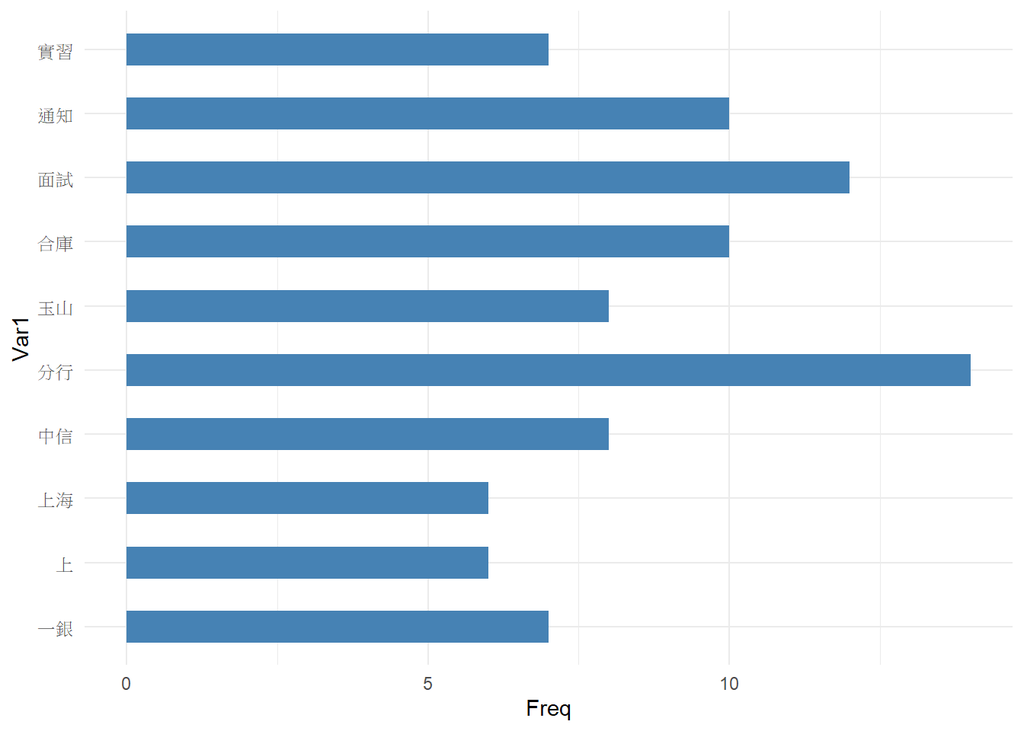

```r
library(ggplot2)
worddata <- head(AllTop,10)
ggplot(worddata, aes(x=Var1,y=Freq))+
  geom_bar(stat="identity",fill="steelblue",width=0.5)+
  coord_flip()+
  theme_minimal()
```

### 由220篇文章中的前十個慣用字，推測在Finance版談論的民眾大部分嚮往銀行的工作，第一商業銀行(一銀)、中信、玉山、合庫四家銀行為其中四個關鍵字，可能也會想到外地工作(上海)，版上也會交換面試、實習相關經驗，Finance版符合商學院的主要出路。

#### 由AllTop畫出文字雲

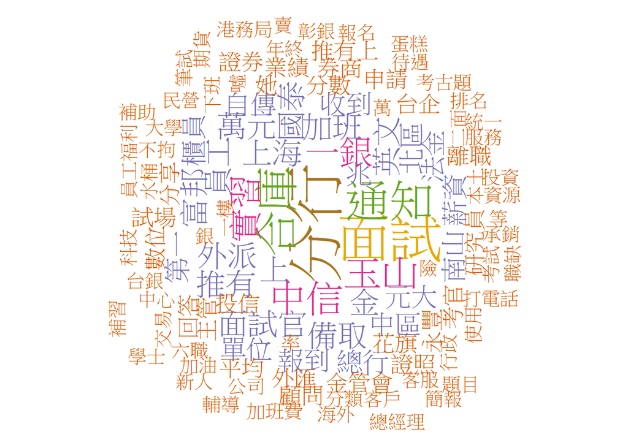

```r
library("tm")
library("SnowballC")
library("wordcloud")
library("RColorBrewer")

wordcloud(words = AllTop$Var1, freq = AllTop$Freq,
          max.words=200, random.order=FALSE, rot.per=0.3,
          colors=brewer.pal(7, "Dark2"))
```

### 二、從220篇文章中歸納彼此相關性最高的關鍵詞

#### TF-IDF:與前面步驟相同，但是不轉置

```r
TopWords = data.frame()
for( id in c(1:n) )
{
  dayMax = order(doc.tfidf[,id+1], decreasing = TRUE)
  showResult = as.data.frame(doc.tfidf[dayMax[1:10],])
  TopWords = rbind(TopWords, showResult)
}
colnames(TopWords) = rownames(doc.tfidf)[1:221]
TopWords = droplevels(TopWords)
kable(head(TopWords))
```

|  | 1 | 2 | 3 | 4 | 5 | 6 | 7 | 8 | 9 | 10 | 11 | 12 | 13 | 14 | 15 | 16 | 17 | 18 | 19 | 20 | 21 | 22 | 23 | 24 | 25 | 26 | 27 | 28 | 29 | … |
| --- | --- | --- | --- | --- | --- | --- | --- | --- | --- | --- | --- | --- | --- | --- | --- | --- | --- | --- | --- | --- | --- | --- | --- | --- | --- | --- | --- | --- | --- | --- |
| 120 | 落地 | 0.0713827 | 0 | 0.0000000 | 0.0000000 | 0.0000000 | 0.0000000 | 0.0000000 | 0 | 0.0000000 | 0.0000000 | 0 | 0 | 0.0000000 | 0 | 0.000000 | 0 | 0 | 0 | 0.0000000 | 0 | 0.0000000 | 0 | 0.000000 | 0.0000000 | 0.000000 | 0 | 0 | 0.0000000 | … |
| 20 | 分行 | 0.0512755 | 0 | 0.0213336 | 0.0065531 | 0.0019349 | 0.0133457 | 0.0095984 | 0 | 0.0062251 | 0.0053237 | 0 | 0 | 0.0000000 | 0 | 0.000000 | 0 | 0 | 0 | 0.0085836 | 0 | 0.0059224 | 0 | 0.013121 | 0.0325831 | 0.001171 | 0 | 0 | 0.0000000 | … |
| 141 | 總行 | 0.0495395 | 0 | 0.0190846 | 0.0000000 | 0.0000000 | 0.0161173 | 0.0309114 | 0 | 0.0000000 | 0.0000000 | 0 | 0 | 0.0000000 | 0 | 0.000000 | 0 | 0 | 0 | 0.0000000 | 0 | 0.0095365 | 0 | 0.000000 | 0.0314800 | 0.000000 | 0 | 0 | 0.0000000 | … |
| 88 | 除了 | 0.0486461 | 0 | 0.0000000 | 0.0000000 | 0.0061190 | 0.0000000 | 0.0000000 | 0 | 0.0000000 | 0.0000000 | 0 | 0 | 0.0060292 | 0 | 0.003112 | 0 | 0 | 0 | 0.0000000 | 0 | 0.0000000 | 0 | 0.000000 | 0.0000000 | 0.000000 | 0 | 0 | 0.0102356 | … |
| 6 | 一體 | 0.0409545 | 0 | 0.0000000 | 0.0000000 | 0.0000000 | 0.0000000 | 0.0000000 | 0 | 0.0000000 | 0.0000000 | 0 | 0 | 0.0000000 | 0 | 0.000000 | 0 | 0 | 0 | 0.0000000 | 0 | 0.0000000 | 0 | 0.000000 | 0.0000000 | 0.000000 | 0 | 0 | 0.0000000 | … |
| 50 | 完只 | 0.0409545 | 0 | 0.0000000 | 0.0000000 | 0.0000000 | 0.0000000 | 0.0000000 | 0 | 0.0000000 | 0.0000000 | 0 | 0 | 0.0000000 | 0 | 0.000000 | 0 | 0 | 0 | 0.0000000 | 0 | 0.0000000 | 0 | 0.000000 | 0.0000000 | 0.000000 | 0 | 0 | 0.0000000 | … |

#### 每一列各自相加，詞對應的數字是220篇文章共同出現的頻率大小

```r
wordfreq <- rowSums( TopWords[,2:221] )
kable(head(wordfreq,10))
```

|  | x |
| --- | --- |
| 120 | 0.0754361 |
| 20 | 0.9371262 |
| 141 | 0.4353170 |
| 88 | 0.2234180 |
| 6 | 0.0409545 |
| 50 | 0.0409545 |
| 51 | 0.0409545 |
| 69 | 0.0409545 |
| 70 | 0.0409545 |
| 85 | 0.0409545 |

#### 將出現的頻率大小進行排序

```r
freq_arranged <- sort(wordfreq,decreasing=T)
kable(head(freq_arranged,35))
```

|  | x |
| --- | --- |
| 419 | 1.699518 |
| 4191 | 1.699518 |
| 4192 | 1.699518 |
| 4193 | 1.699518 |
| 4194 | 1.699518 |
| 4195 | 1.699518 |
| 4196 | 1.699518 |
| 4197 | 1.699518 |
| 4198 | 1.699518 |
| 4199 | 1.699518 |
| 41910 | 1.699518 |
| 41912 | 1.699518 |
| 133 | 1.663278 |
| 1332 | 1.663278 |
| 740 | 1.384627 |
| 7401 | 1.384627 |
| 7402 | 1.384627 |
| 7403 | 1.384627 |
| 7404 | 1.384627 |
| 7405 | 1.384627 |
| 898 | 1.147051 |
| 8981 | 1.147051 |
| 8982 | 1.147051 |
| 8983 | 1.147051 |
| 8984 | 1.147051 |
| 8986 | 1.147051 |
| 8987 | 1.147051 |
| 8988 | 1.147051 |
| 1378 | 1.041083 |
| 13781 | 1.041083 |
| 13782 | 1.041083 |
| 13783 | 1.041083 |
| 13784 | 1.041083 |
| 13785 | 1.041083 |
| 13786 | 1.041083 |

#### 找出文章間關聯最大的五個詞

```r
TDM[c(419,133,740,898,1378),1]
```

```
## [1] "面試" "編輯" "推有" "玉山" "通知"
```

### 結論 : 由一、知道ptt-Finance版文章中主要關鍵詞為:分行、面試、通知、合庫、玉山、中信；而這些文章間關聯性最大的詞為:面試、 編輯、推有、玉山、通知。可以推論群眾討論的話題主要是面試經驗，只因部分民眾在某幾篇文章中談論到銀行，才使關鍵詞產生變化。